# 201.10. Visit table

For the Rubin Science Platform at data.lsst.cloud.  
Data Release: [Data Preview 2](https://dp2.lsst.io/)  
Container Size: Large  
LSST Science Pipelines version: r30.0.10  
Last verified to run: 2026-07-24  
Repository: github.com/lsst/tutorial-notebooks  
DOI: 10.11578/rubin/dc.20250909.20

**Learning objective:** To understand the contents of the `Visit` table and how to access it.

**LSST data products:** `Visit`

**Packages:** `lsst.rsp`, `lsst.daf.butler`

**Credit:** Originally developed by the Rubin Community Science team. Please consider acknowledging them if this notebook is used for the preparation of journal articles, software releases, or other notebooks.

**Get Support:** Everyone is encouraged to ask questions or raise issues in the [Support Category](https://community.lsst.org/c/support) of the Rubin Community Forum.Rubin staff will respond to all questions posted there.

## 1. Introduction

A `Visit` refers to an observation of the sky with the camera.

The `Visit` table contains data about the individual observations, such as the coordinates, date, time, filter, camera rotation, exposure time, and airmass. This table does not contain the image data or data for astrophysical sources.

The contents of the `Visit` table are associated with the boresight of the **entire focal plane**. By contrast, the `VisitDetector` table contains data by individual detectors of the camera, instead of the entire focal plane.

- TAP table name: `dp2.Visit`
- Butler table name: `visit_table`
- columns: 15
- rows: 28,698

**Related tutorials:** The tutorial for the `VisitDetector` table is also in this series. The TAP and Butler data access services are demonstrated in the 100-level "How to" tutorials.

### 1.1. Import packages

Import standard python packages `re`, `numpy`, `matplotlib`, and `astropy`.

From the `lsst` package, import modules for the TAP service and the Butler.

```python
import re
import numpy as np
import matplotlib.pyplot as plt
from lsst.rsp import RSPDiscovery
from lsst.daf.butler import Butler
from lsst.utils.plotting import (get_multiband_plot_colors,
                                 get_multiband_plot_symbols)
```

### 1.2. Define parameters and functions

Create an instance of the TAP service.

```python
discovery = RSPDiscovery("dp2")
tap_service = discovery.get_tap_client()
```

Create an instance of the Rubin data Butler.

```python
butler = Butler("dp2", collections="dp2")
```

Define the colors and symbols to represent the LSST filters in plots.

```python
filter_colors = get_multiband_plot_colors()
filter_names = filter_colors.keys()
filter_symbols = get_multiband_plot_symbols()
```

## 2. Schema (columns)

To browse the table schema visit the [Rubin schema browser](https://sdm-schemas.lsst.io/), or use the TAP service via the Portal Aspect or as demonstrated in Section 2.1.

### 2.1. Retrieve table schema

To retrieve the table schema, define a query for the schema columns of the `Visit` table and run the query job.

```python
query = "SELECT column_name, datatype, description, unit " \
        "FROM tap_schema.columns " \
        "WHERE table_name = 'dp2.Visit'"
job = tap_service.submit_job(query)
job.run()
job.wait(phases=['COMPLETED', 'ERROR'])
print('Job phase is', job.phase)
if job.phase == 'ERROR':
    job.raise_if_error()
```

```
Job phase is COMPLETED
```

Retrieve the query results and display them as an `astropy` table with the `to_table()` attribute.

```python
assert job.phase == 'COMPLETED'
results = job.fetch_result().to_table()
results
```

*Table length=15*

| column_name str64 | datatype str64 | description str512 | unit str64 |
| --- | --- | --- | --- |
| airmass | double | Airmass of the observed line of sight. |  |
| altitude | double | Altitude of focal plane center at the middle of the visit. | deg |
| azimuth | double | Azimuth of focal plane center at the middle of the visit. | deg |
| band | char | Name of the band used to take the visit where this source was measured. Abstract filter that is not associated with a particular instrument. |  |
| dec | double | Declination of focal plane center | deg |
| expMidpt | char | Midpoint time for exposure at the fiducial center of the focal plane array. TAI, accurate to 10ms. |  |
| expMidptMJD | double | Midpoint time for exposure at the fiducial center of the focal plane array in MJD. TAI, accurate to 10ms. | d |
| expTime | double | Spatially-averaged duration of visit, accurate to 10ms. | s |
| obsStart | char | Start time of the visit at the fiducial center of the focal plane array, TAI, accurate to 10ms. |  |
| obsStartMJD | double | Start of the exposure in MJD, TAI, accurate to 10ms. | d |
| physical_filter | char | ID of physical filter, the filter associated with a particular instrument. |  |
| ra | double | Right Ascension of focal plane center. | deg |
| skyRotation | double | Sky rotation angle. | deg |
| visit | long | Unique identifier. |  |
| zenithDistance | double | Zenith distance at the middle of the visit. | deg |

The table displayed above has not been truncated, as it is only 15 rows long.

Option to use the regular expressions package `re` to search for columns for which the description contains the string `temp`.

```python
# temp = 'time'
# temp = 'filt'
# temp = 'exp'
# for c, desc in enumerate(results['description']):
#     if re.search(temp, desc):
#         print(results['column_name'][c])
```

Delete the job and the `results`.

```python
del query, results
job.delete()
```

## 3. Data access

The `Visit` table is available via the TAP service and the Butler.

**Recommended access method:** TAP.

### 3.1. TAP (Table Access Protocol)

The `Visit` table is stored in Qserv and accessible via the TAP services using ADQL queries.

#### 3.1.2. Demo query

**Avoid full-table queries.** Although the `Visit` table is relatively small compared to source measurement tables, it is good practice to always include spatial constraints and only retrieve necessary columns.

Search for g- and r-band visits within 3 degrees of the center of the Extended Chandra Deep Field South (ECDFS) field, RA, Dec = $53.13 -28.10$. Return the visit identifier, RA, Dec, and the midpoint time of the exposure in MJD.

```python
query = "SELECT visit, ra, dec, band, expMidptMJD " \
        "FROM dp2.Visit " \
        "WHERE CONTAINS(POINT('ICRS', ra, dec), " \
        "CIRCLE('ICRS', 53.13, -28.10, 3)) = 1 " \
        "AND (band = 'r' OR band = 'g')"
job = tap_service.submit_job(query)
job.run()
job.wait(phases=['COMPLETED', 'ERROR'])
print('Job phase is', job.phase)
if job.phase == 'ERROR':
    job.raise_if_error()
```

```
Job phase is COMPLETED
```

Fetch the results as an `astropy` table.

```python
assert job.phase == 'COMPLETED'
results = job.fetch_result().to_table()
print(len(results))
```

```
114
```

Option to display the table.

```python
# results
```

As an example, plot the RA and Dec for the g- and r-band visits, and the cumulative distribution of observation MJDs.

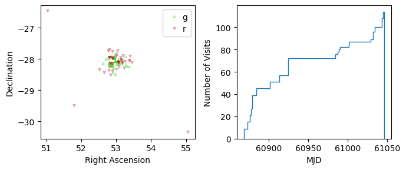

```python
fig, (ax1, ax2) = plt.subplots(1, 2, figsize=(7, 3))
for filt in filter_names:
    fx = np.where(results['band'] == filt)[0]
    if len(fx) > 0:
        ax1.plot(results['ra'][fx], results['dec'][fx],
                 filter_symbols[filt], ms=5, mew=0, alpha=0.4,
                 color=filter_colors[filt], label=filt)
ax1.set_xlabel('Right Ascension')
ax1.set_ylabel('Declination')
ax1.legend(loc='best', handletextpad=0)
ax2.hist(results['expMidptMJD'], len(results),
         histtype='step', cumulative=True)
ax2.set_xlabel('MJD')
ax2.set_ylabel('Number of Visits')
plt.tight_layout()
plt.show()
```

> **Figure 1:** At left, the RA vs. Dec of the g- and r-band visits (central boresight of the focal plane). At right, the cumulative number of visits as a function of time in MJD.

Clean up.

```python
job.delete()
del query, results
```

#### 3.2.2. Joinable tables

The `Visit` table can be joined with any table that has a `visit` or `visitId` column (they have the same values). This includes the `VisitDetector`, `Source`, `ForcedSource`, `DiaSource`, and `ForcedSourceOnDiaObject` tables.

##### VisitDetector

```python
query = """SELECT v.visit, v.expMidptMJD, v.band, vd.detector,
        AVG(vd.seeing) AS mean_seeing, AVG(vd.magLim) AS mean_maglim
        FROM dp2.Visit AS v
        JOIN dp2.VisitDetector AS vd ON v.visit = vd.visitId
        WHERE CONTAINS(POINT('ICRS', v.ra, v.dec), CIRCLE('ICRS', 150.1, 2.1, 2)) = 1
        AND (v.expMidptMJD > 60818.7 AND v.expMidptMJD < 60819.7)
        GROUP BY v.visit"""
job = tap_service.submit_job(query)
job.run()
job.wait(phases=['COMPLETED', 'ERROR'])
print('Job phase is', job.phase)
if job.phase == 'ERROR':
    job.raise_if_error()
```

```
Job phase is COMPLETED
```

```python
assert job.phase == 'COMPLETED'
results = job.fetch_result().to_table()
print(len(results))
```

```
114
```

Option to display the table.

```python
# results
```

Plot the mean seeing versus the time of the visit, to show how seeing changed over the night, and versus the magnitude limit, to show how seeing and depth are correlated.

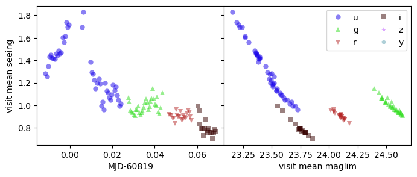

```python
fig, ax = plt.subplots(1, 2, figsize=(8, 3), sharey=True)
for f, filt in enumerate(filter_names):
    fx = np.where(results['band'] == filt)[0]
    ax[0].plot(results['expMidptMJD'][fx]-60819, results['mean_seeing'][fx],
               filter_symbols[filt], mew=0, alpha=0.5, color=filter_colors[filt], label=filt)
    ax[1].plot(results['mean_maglim'][fx], results['mean_seeing'][fx],
               filter_symbols[filt], mew=0, alpha=0.5, color=filter_colors[filt], label=filt)
ax[0].set_xlabel('MJD-60819')
ax[0].set_ylabel('visit mean seeing')
ax[1].set_xlabel('visit mean maglim')
plt.legend(loc='upper right', ncol=2)
fig.subplots_adjust(wspace=0)
plt.show()
```

> **Figure 2:** At left, the mean seeing over all detectors per visit vs. the MJD of the visit, showing how the seeing changed over the course of the night. At right, the mean seeing vs. the mean magnitude limit over all detectors, to show how seeing and depth are related.

```python
del query, results
job.delete()
```

##### Source

Joins to the `Source`, `ForcedSource`, `DiaSource`, and `ForcedSourceOnDiaObject` tables all similarly use the column `visit`.

As an example, start with a similar query as above, but join to the `Source` table, which contains $>5\sigma$ detections in the processed visit image, and return the number of sources detected per visit (over all detectors).

```python
query = """SELECT v.visit, v.expMidptMJD, v.band, COUNT(s.sourceId) AS ndetections
        FROM dp2.Visit AS v
        JOIN dp2.Source AS s ON v.visit = s.visit
        WHERE CONTAINS(POINT('ICRS', v.ra, v.dec), CIRCLE('ICRS', 150.1, 2.1, 2)) = 1
        AND (v.expMidptMJD > 60818.7 AND v.expMidptMJD < 60819.7)
        GROUP BY v.visit"""
job = tap_service.submit_job(query)
job.run()
job.wait(phases=['COMPLETED', 'ERROR'])
print('Job phase is', job.phase)
if job.phase == 'ERROR':
    job.raise_if_error()
assert job.phase == 'COMPLETED'
results = job.fetch_result().to_table()
```

```
Job phase is COMPLETED
```

Plot the number of sources detected per visit as a function of time over the night.

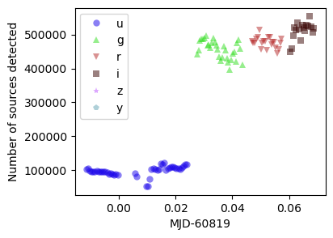

```python
fig = plt.figure(figsize=(4, 3))
for f, filt in enumerate(filter_names):
    fx = np.where(results['band'] == filt)[0]
    plt.plot(results['expMidptMJD'][fx]-60819, results['ndetections'][fx],
             filter_symbols[filt], mew=0, alpha=0.5, color=filter_colors[filt], label=filt)
plt.xlabel('MJD-60819')
plt.ylabel('Number of sources detected')
plt.legend(loc='upper left', ncol=1)
plt.show()
```

> **Figure 3:** Number of sources detected per visit image vs. time. Compare with Figure 2, and notice that when the seeing for the $u$-band images was poor, fewer sources were detected. That more sources are detected in the $gri$ bands compared to the $u$ band is likely mostly due to the fact that LSST images are deeper in the $gri$-bands, but also due to the improving image quality over the night.

```python
del query, results
job.delete()
```

### 3.2. Butler

Show that the only dimension for the `visit_table` is instrument, and that it is required.

```python
butler.get_dataset_type('visit_table')
```

```
DatasetType('visit_table', {instrument}, ArrowAstropy)
```

```python
butler.get_dataset_type('visit_table').dimensions.required
```

```
{instrument}
```

Show that there is only one dataset reference for the "LSSTCam" `visit_table`.

```python
dataset_refs = butler.query_datasets("visit_table", instrument="LSSTCam")
print(len(dataset_refs))
print(dataset_refs[0])
```

```
1
visit_table@{instrument: 'LSSTCam'} [sc=ArrowAstropy] (run=LSSTCam/runs/DRP/DP2/v30_0_0/DM-53881/stage2/20260325T031924Z id=019d2301-62c9-7b3b-a3a2-78c7d9adabf0)
```

Retrieve the entire `visit_table`.

```python
visit_table = butler.get(dataset_refs[0])
print(len(visit_table))
```

```
28698
```

Option to display the table (automatically truncated).

```python
visit_table
```

*Table length=28698*

| visitId int64 | visit int64 | physical_filter str4 | band str1 | ra float64 | dec float64 | decl float64 | skyRotation float64 | azimuth float64 | altitude float64 | zenithDistance float64 | airmass float64 | expTime float64 | expMidpt datetime64[ns] | expMidptMJD float64 | obsStart datetime64[ns] | obsStartMJD float64 |
| --- | --- | --- | --- | --- | --- | --- | --- | --- | --- | --- | --- | --- | --- | --- | --- | --- |
| 2025042400172 | 2025042400172 | r_57 | r | 185.443060811076 | 5.98102138504802 | 5.98102138504802 | 146.113088289607 | 1.9614440076983797 | 53.8990970549479 | 36.1009029450521 | 1.23704795139999 | 29.999915599823 | 2025-04-25T02:48:48.447066101 | 60790.11722739659 | 2025-04-25T02:48:33.447108302 | 60790.11705378597 |
| 2025042400173 | 2025042400173 | r_57 | r | 187.349245626471 | 8.23604638508455 | 8.23604638508455 | 144.18450391305 | 4.59267468721633 | 51.5610973958556 | 38.4389026041444 | 1.27595524322485 | 30.0000872612 | 2025-04-25T02:49:32.773247240 | 60790.1177404311 | 2025-04-25T02:49:17.773203610 | 60790.117566819485 |
| 2025042400174 | 2025042400174 | r_57 | r | 186.443750064719 | 7.16885705640284 | 7.16885705640284 | 138.496645426916 | 2.93858842208796 | 52.6885249328851 | 37.3114750671149 | 1.2566323773581 | 30.0009806156158 | 2025-04-25T02:50:16.561317680 | 60790.11824723747 | 2025-04-25T02:50:01.560827373 | 60790.11807362069 |
| 2025042400175 | 2025042400175 | r_57 | r | 185.542702196852 | 6.0999042479778 | 6.0999042479778 | 132.754022698538 | 1.19423996978959 | 53.7910062641441 | 36.2089937358559 | 1.23874981794006 | 30.0010826587677 | 2025-04-25T02:51:00.667260028 | 60790.118757722914 | 2025-04-25T02:50:45.666718699 | 60790.118584105534 |
| 2025042400176 | 2025042400176 | r_57 | r | 187.450364693337 | 8.35450149584232 | 8.35450149584232 | 130.813892358106 | 3.8613155396456 | 51.471714859197 | 38.528285140803 | 1.27753357366488 | 30.0010211467743 | 2025-04-25T02:51:45.309465548 | 60790.11927441511 | 2025-04-25T02:51:30.308954975 | 60790.11910079809 |
| 2025042400177 | 2025042400177 | r_57 | r | 185.847533564225 | 5.8013629485669 | 5.8013629485669 | 124.211898222169 | 1.09097214771777 | 54.0905751934753 | 35.9094248065247 | 1.23405624396335 | 30.0000793933868 | 2025-04-25T02:52:29.479243963 | 60790.1197856394 | 2025-04-25T02:52:14.479204267 | 60790.119612027825 |
| 2025042400178 | 2025042400178 | r_57 | r | 187.75336753586 | 8.05638192333976 | 8.05638192333976 | 122.26067429917401 | 3.78158433488536 | 51.7731307887482 | 38.2268692112518 | 1.27223856646967 | 30.0000307559967 | 2025-04-25T02:53:14.019002678 | 60790.120301145864 | 2025-04-25T02:52:59.018987301 | 60790.120127534574 |
| 2025042400179 | 2025042400179 | r_57 | r | 186.848285643417 | 6.98916841538782 | 6.98916841538782 | 116.584389074444 | 2.09978127522019 | 52.8876775587752 | 37.1123224412248 | 1.25332980626234 | 30.0011038780212 | 2025-04-25T02:53:57.435132769 | 60790.12080364737 | 2025-04-25T02:53:42.434580830 | 60790.12063002987 |
| 2025042400180 | 2025042400180 | r_57 | r | 185.947406877035 | 5.92024017591185 | 5.92024017591185 | 110.853352061965 | 0.324268956119887 | 53.9765162094151 | 36.0234837905849 | 1.23583528164551 | 30.001017332077 | 2025-04-25T02:54:41.342426384 | 60790.12131183364 | 2025-04-25T02:54:26.341917718 | 60790.12113821664 |
| 2025042400181 | 2025042400181 | r_57 | r | 187.854178952975 | 8.17485614320666 | 8.17485614320666 | 108.889140076339 | 3.05461494718365 | 51.6779416096108 | 38.3220583903892 | 1.27390252171799 | 30.0010986328125 | 2025-04-25T02:55:25.650037865 | 60790.121824653215 | 2025-04-25T02:55:10.649488549 | 60790.12165103575 |
| 2025042400182 | 2025042400182 | r_57 | r | 185.643272826363 | 5.82455052931297 | 5.82455052931297 | 101.413213591773 | 359.170162068308 | 54.0697005466828 | 35.9302994533172 | 1.23438151518466 | 30.0009999275208 | 2025-04-25T02:56:11.504936034 | 60790.1223553812 | 2025-04-25T02:55:56.504436071 | 60790.1221817643 |
| 2025042400183 | 2025042400183 | r_57 | r | 187.548868127399 | 8.07957103672195 | 8.07957103672195 | 99.4773854200115 | 1.96819834655187 | 51.799135130418 | 38.200864869582 | 1.27178609798797 | 30.0000410079956 | 2025-04-25T02:56:56.175039188 | 60790.122872396285 | 2025-04-25T02:56:41.175018685 | 60790.12269878494 |
| 2025042400184 | 2025042400184 | r_57 | r | 186.643642983593 | 7.01236130557526 | 7.01236130557526 | 93.7939908514344 | 0.23080595724814604 | 52.8845273212575 | 37.1154726787425 | 1.25338230487889 | 30.0009963512421 | 2025-04-25T02:57:40.277875125 | 60790.12338284578 | 2025-04-25T02:57:25.277376950 | 60790.1232092289 |
| 2025042400185 | 2025042400185 | r_57 | r | 185.74296324523 | 5.94343339020704 | 5.94343339020704 | 88.0557569749744 | 358.405719627179 | 53.9425446952639 | 36.0574553047361 | 1.23636770363808 | 30.0015485286713 | 2025-04-25T02:58:24.115260667 | 60790.12389022292 | 2025-04-25T02:58:09.114486403 | 60790.12371660285 |
| 2025042400186 | 2025042400186 | r_57 | r | 187.649548118849 | 8.19804244067103 | 8.19804244067103 | 86.1072978524376 | 1.23746467867062 | 51.6916653751537 | 38.3083346248463 | 1.2736627900196 | 30.000072479248 | 2025-04-25T02:59:08.988900881 | 60790.12440959376 | 2025-04-25T02:58:53.988864642 | 60790.12423598223 |
| 2025042400187 | 2025042400187 | r_57 | r | 185.471185060866 | 5.40272571999455 | 5.40272571999455 | 78.6773665715572 | 357.269104572305 | 54.4618234361368 | 35.5381765638632 | 1.22833577987909 | 30.0000083446503 | 2025-04-25T02:59:54.784825364 | 60790.12493963918 | 2025-04-25T02:59:39.784821192 | 60790.12476602802 |
| 2025042400196 | 2025042400196 | r_57 | r | 187.375759288216 | 7.65773974047271 | 7.65773974047271 | 76.7771396265029 | 356.009600141957 | 52.1651008975808 | 37.8348991024192 | 1.2654716067816 | 30.0010366439819 | 2025-04-25T03:10:59.607578071 | 60790.13263434697 | 2025-04-25T03:10:44.607059750 | 60790.13246072986 |
| 2025042400197 | 2025042400197 | r_57 | r | 186.471352630398 | 6.59047894909582 | 6.59047894909582 | 71.0778573822967 | 354.098026626793 | 53.1484082858814 | 36.8515917141186 | 1.249056835455 | 30.0000202655792 | 2025-04-25T03:11:44.276698427 | 60790.133151350674 | 2025-04-25T03:11:29.276688295 | 60790.13297773944 |
| 2025042400198 | 2025042400198 | r_57 | r | 185.571123624513 | 5.5215965200526 | 5.5215965200526 | 65.3217871312681 | 352.104923397705 | 54.0994779180869 | 35.9005220819131 | 1.23392031530375 | 30.0010199546814 | 2025-04-25T03:12:27.949494085 | 60790.13365682284 | 2025-04-25T03:12:12.948984108 | 60790.13348320583 |
| 2025042400199 | 2025042400199 | r_57 | r | 187.476036005872 | 7.77622613594882 | 7.77622613594882 | 63.40768732720059 | 355.285768490359 | 52.0168762045619 | 37.9831237954381 | 1.2680154599723 | 30.0000410079956 | 2025-04-25T03:13:13.054631973 | 60790.13417887305 | 2025-04-25T03:12:58.054611470 | 60790.1340052617 |
| 2025042400200 | 2025042400200 | g_6 | g | 185.003510815524 | 5.73722306768995 | 5.73722306768995 | 115.74918068646798 | 349.748539942318 | 53.6900581532369 | 36.3099418467631 | 1.24034927851352 | 30.0009922981262 | 2025-04-25T03:15:56.287972419 | 60790.136068147825 | 2025-04-25T03:15:41.287476270 | 60790.13589453097 |
| 2025042400201 | 2025042400201 | g_6 | g | 186.908911727528 | 7.992241362986901 | 7.992241362986901 | 113.868776161353 | 353.015994748226 | 51.6751050394469 | 38.3248949605531 | 1.27395508160137 | 30.0010890960693 | 2025-04-25T03:16:42.111012904 | 60790.13659850709 | 2025-04-25T03:16:27.110468356 | 60790.13642488967 |
| ... | ... | ... | ... | ... | ... | ... | ... | ... | ... | ... | ... | ... | ... | ... | ... | ... |
| 2026010600076 | 2026010600076 | y_10 | y | 138.353042498328 | -18.5389260682848 | -18.5389260682848 | 31.0068726669446 | 296.296570383063 | 67.6315341837999 | 22.3684658162001 | 1.08120376172672 | 30.0009903907776 | 2026-01-07T08:15:30.831623582 | 61047.34410684749 | 2026-01-07T08:15:15.831128387 | 61047.34393323065 |
| 2026010600077 | 2026010600077 | y_10 | y | 141.103611443935 | -16.8121445806364 | -16.8121445806364 | 38.4170930275092 | 303.957300944051 | 68.4838707873255 | 21.5161292126745 | 1.07475729455947 | 30.0011456012726 | 2026-01-07T08:16:15.572810030 | 61047.3446246853 | 2026-01-07T08:16:00.572237230 | 61047.344451067554 |
| 2026010600078 | 2026010600078 | y_10 | y | 138.643347516893 | -15.397498367409598 | -15.397498367409598 | 37.3652290462123 | 302.435475292662 | 65.6492602969923 | 24.350739703007704 | 1.09744745467064 | 30.0010118484497 | 2026-01-07T08:16:56.472042406 | 61047.345098056045 | 2026-01-07T08:16:41.471536482 | 61047.34492443908 |
| 2026010600079 | 2026010600079 | y_10 | y | 135.891372596865 | -17.0930198908701 | -17.0930198908701 | 30.995638017845998 | 295.166393428926 | 64.4580421427495 | 25.541957857250495 | 1.10808884250446 | 30.0011303424835 | 2026-01-07T08:17:41.531779181 | 61047.34561958078 | 2026-01-07T08:17:26.531214010 | 61047.34544596313 |
| 2026010600080 | 2026010600080 | y_10 | y | 133.05755146353 | -18.7249059991847 | -18.7249059991847 | 25.3695142826721 | 288.592993075444 | 62.90935736267289 | 27.090642637327107 | 1.12297336656401 | 30.0010375976562 | 2026-01-07T08:18:25.591673771 | 61047.34612953327 | 2026-01-07T08:18:10.591154973 | 61047.34595591615 |
| 2026010600081 | 2026010600081 | y_10 | y | 129.892776962173 | -19.8632039752361 | -19.8632039752361 | 21.214660682387 | 283.328428361972 | 60.671091329055805 | 29.328908670944195 | 1.14669673664692 | 30.001128911972 | 2026-01-07T08:19:06.730246369 | 61047.346605674145 | 2026-01-07T08:18:51.729681914 | 61047.3464320565 |
| 2026010600082 | 2026010600082 | y_10 | y | 130.625235397626 | -17.1540539176332 | -17.1540539176332 | 26.2444673789574 | 288.631034301704 | 59.84245389708029 | 30.15754610291971 | 1.15619533303991 | 30.001029253006 | 2026-01-07T08:19:46.412328961 | 61047.34706495751 | 2026-01-07T08:19:31.411814335 | 61047.34689134044 |
| 2026010600083 | 2026010600083 | y_10 | y | 133.460972510709 | -15.613403346366102 | -15.613403346366102 | 31.0790349573728 | 294.074042359234 | 61.1597243974878 | 28.8402756025122 | 1.14128347488908 | 30.0011100769043 | 2026-01-07T08:20:25.985890109 | 61047.34752298484 | 2026-01-07T08:20:10.985335071 | 61047.34734936731 |
| 2026010600084 | 2026010600084 | y_10 | y | 136.213892470239 | -13.9566184802745 | -13.9566184802745 | 36.6207633575132 | 300.032716329996 | 62.157032505725795 | 27.842967494274205 | 1.13064664164595 | 30.0010030269623 | 2026-01-07T08:21:04.885682714 | 61047.347973213924 | 2026-01-07T08:20:49.885181201 | 61047.34779959701 |
| 2026010600085 | 2026010600085 | y_10 | y | 138.620586800191 | -12.1906598051242 | -12.1906598051242 | 42.3297986010708 | 306.004303955258 | 62.6076426419637 | 27.3923573580363 | 1.12601301590806 | 30.001140832901 | 2026-01-07T08:21:44.168852685 | 61047.348427880235 | 2026-01-07T08:21:29.168282269 | 61047.34825426252 |
| 2026010600086 | 2026010600086 | y_10 | y | 136.001652974444 | -10.7669089150578 | -10.7669089150578 | 40.8453498332702 | 304.221110033005 | 59.647548103660995 | 30.352451896339005 | 1.15848327904462 | 30.0010223388672 | 2026-01-07T08:22:25.357565164 | 61047.348904601444 | 2026-01-07T08:22:10.357053995 | 61047.34873098441 |
| 2026010600087 | 2026010600087 | y_10 | y | 133.760896235304 | -12.5006467580703 | -12.5006467580703 | 36.0131183591272 | 298.623495630718 | 59.0037120227157 | 30.996287977284297 | 1.16621288338317 | 30.0011458396912 | 2026-01-07T08:23:06.567991314 | 61047.34938157398 | 2026-01-07T08:22:51.567418395 | 61047.349207956235 |
| 2026010600088 | 2026010600088 | y_10 | y | 131.004008103533 | -14.0680703149896 | -14.0680703149896 | 31.2149722542582 | 292.985276687941 | 57.65984915686689 | 32.34015084313311 | 1.18316805496568 | 30.0000126361847 | 2026-01-07T08:23:47.912575026 | 61047.349860099246 | 2026-01-07T08:23:32.912568708 | 61047.349686488065 |
| 2026010600089 | 2026010600089 | y_10 | y | 128.922131569874 | -12.7224484226276 | -12.7224484226276 | 31.3479177750898 | 292.713070642803 | 55.0945613187255 | 34.9054386812745 | 1.21883782699736 | 30.0011267662048 | 2026-01-07T08:24:28.521746833 | 61047.35033011281 | 2026-01-07T08:24:13.521183450 | 61047.35015649517 |
| 2026010600090 | 2026010600090 | y_10 | y | 128.234985835844 | -15.060516130309 | -15.060516130309 | 27.7152050211811 | 288.474793024401 | 55.6879969989798 | 34.3120030010202 | 1.21017945066323 | 30.0009865760803 | 2026-01-07T08:25:09.405668435 | 61047.35080330635 | 2026-01-07T08:24:54.405175147 | 61047.35062968953 |
| 2026010600091 | 2026010600091 | y_10 | y | 127.41470931520699 | -17.7826049271 | -17.7826049271 | 23.2556677088549 | 283.416735439661 | 56.216183668355 | 33.783816331645 | 1.20267552647979 | 30.0011241436005 | 2026-01-07T08:25:50.732561790 | 61047.35128162687 | 2026-01-07T08:25:35.731999719 | 61047.35110800925 |
| 2026010600092 | 2026010600092 | y_10 | y | 126.590722616156 | -20.4325004065026 | -20.4325004065026 | 18.7253776461487 | 278.375428095406 | 56.528285584998 | 33.471714415002 | 1.19834110308217 | 30.0000422000885 | 2026-01-07T08:26:32.322238779 | 61047.351762988874 | 2026-01-07T08:26:17.322217679 | 61047.35158937752 |
| 2026010600093 | 2026010600093 | y_10 | y | 125.740662145996 | -23.0704782854122 | -23.0704782854122 | 14.098453826005 | 273.293105692965 | 56.638036133845 | 33.361963866155 | 1.1968324566164 | 30.0001401901245 | 2026-01-07T08:27:14.098462505 | 61047.35224650998 | 2026-01-07T08:26:59.098392410 | 61047.35207289806 |
| 2026010600094 | 2026010600094 | y_10 | y | 123.272973903175 | -20.8997951288636 | -20.8997951288636 | 16.9469753126522 | 275.260962624777 | 53.5748889354796 | 36.4251110645204 | 1.24219724042565 | 30.0010330677032 | 2026-01-07T08:27:53.016681885 | 61047.35269695234 | 2026-01-07T08:27:38.016165352 | 61047.35252333525 |
| 2026010600095 | 2026010600095 | y_10 | y | 124.158022602301 | -18.2724979712791 | -18.2724979712791 | 21.0235633044719 | 279.718555179535 | 53.0904674786764 | 36.9095325213236 | 1.25001105172445 | 30.0011253356934 | 2026-01-07T08:28:37.002838078 | 61047.35320605137 | 2026-01-07T08:28:22.002275411 | 61047.35303243375 |
| 2026010600096 | 2026010600096 | y_10 | y | 125.064263130519 | -15.6133713201472 | -15.6133713201472 | 25.0628841004994 | 284.150017134643 | 52.4804903284725 | 37.5195096715275 | 1.26012991438198 | 30.0010321140289 | 2026-01-07T08:29:16.378595106 | 61047.3536617893 | 2026-01-07T08:29:01.378079049 | 61047.353488172215 |
| 2026010600097 | 2026010600097 | y_10 | y | 126.430329088784 | -12.802241260758 | -12.802241260758 | 29.4566056910548 | 289.056891075302 | 52.0209479030687 | 37.9790520969313 | 1.26795229243855 | 30.0011446475983 | 2026-01-07T08:29:55.847315860 | 61047.354118603194 | 2026-01-07T08:29:40.846743537 | 61047.35394498546 |

Display one row of the table.

```python
tx = np.where(visit_table['visit'] == 2026010600097)[0]
visit_table[tx[0]]
```

*Row index=28697*

| visitId int64 | visit int64 | physical_filter str4 | band str1 | ra float64 | dec float64 | decl float64 | skyRotation float64 | azimuth float64 | altitude float64 | zenithDistance float64 | airmass float64 | expTime float64 | expMidpt datetime64[ns] | expMidptMJD float64 | obsStart datetime64[ns] | obsStartMJD float64 |
| --- | --- | --- | --- | --- | --- | --- | --- | --- | --- | --- | --- | --- | --- | --- | --- | --- |
| 2026010600097 | 2026010600097 | y_10 | y | 126.430329088784 | -12.802241260758 | -12.802241260758 | 29.4566056910548 | 289.056891075302 | 52.0209479030687 | 37.9790520969313 | 1.26795229243855 | 30.0011446475983 | 2026-01-07T08:29:55.847315860 | 61047.354118603194 | 2026-01-07T08:29:40.846743537 | 61047.35394498546 |

Clean up.

```python
del dataset_refs, visit_table, tx
```